# Module 9: Putting It All Together — An Atlas of the Exposome

## Overview

This module walks through a large-scale ExWAS that applies **everything** from Modules 1-8:

**Patel CJ, Ioannidis JPA, Manrai AK.** An atlas of exposome-phenome associations in health and disease risk. *Nature Medicine*, in press.

- 619 exposures \(\times\) 305 phenotypes \(\times\) 10 NHANES waves
- ~120,000 associations tested
- Built using the `nhanespewas` R package you learned in Modules 4-7

## From Course to Practice

| Module | Concept | How It Was Used |
| --- | --- | --- |
| 1 | Exposome definition, NHANES | 10 NHANES waves, 1999-2018 |
| 2 | Tidyverse pipelines | Data wrangling at scale |
| 3 | Survey design, FDR, scaling | svyglm, Bonferroni + BY-FDR |
| 4 | nhanespewas package | Core analysis engine |
| 5 | ExWAS loop | 120K associations with tryCatch |
| 6 | Volcano plots, replication | Atlas visualization, 10-wave replication |
| 7 | Meta-analysis, interactions | UWLS meta-analysis across waves |
| 8 | AI agents | Future automation of atlas updates |

## The P-ExWAS: Study Design at a Glance

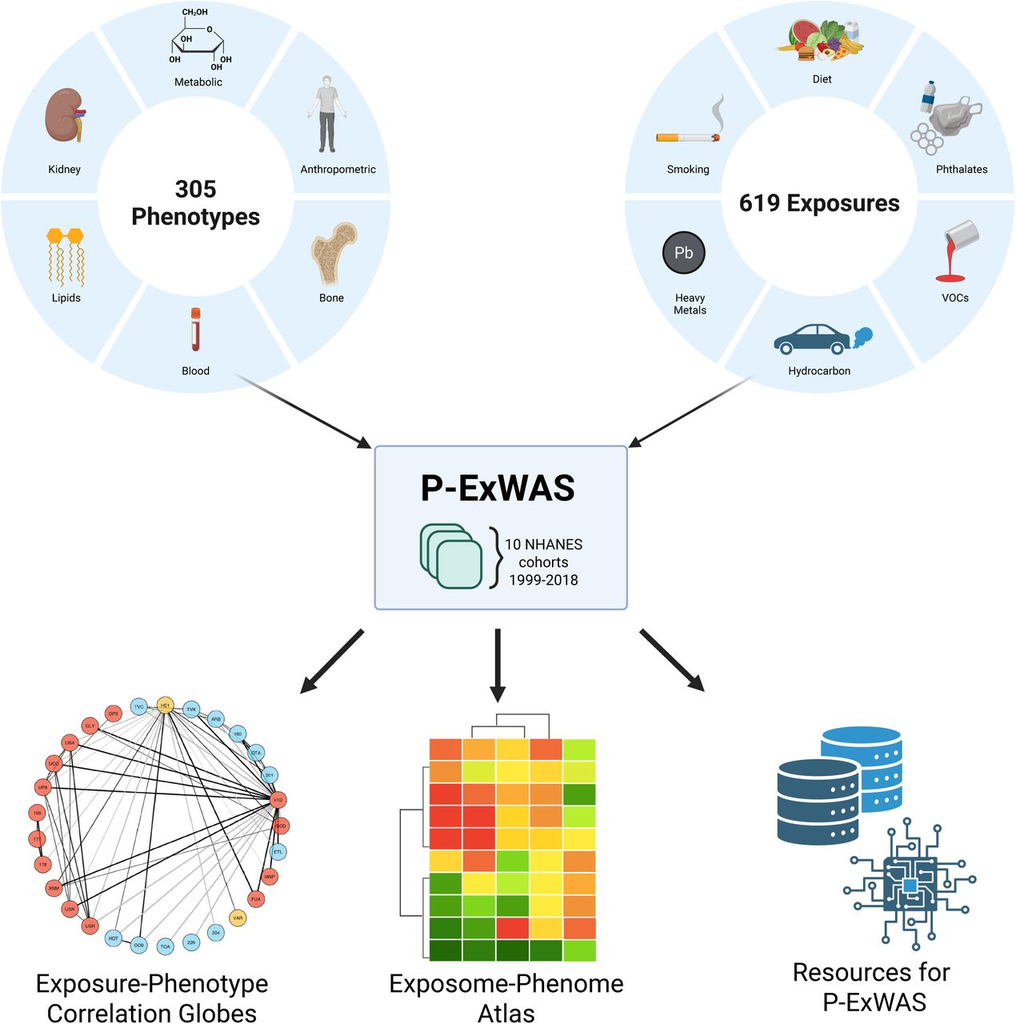

**Figure 1**: The P-ExWAS study design. 305 phenotypes and 619 exposures across 10 NHANES cohorts (1999-2018) are combined into the Exposome-Phenome Atlas, correlation globes, and open-source computational resources.

## The P-ExWAS Analytical Pipeline

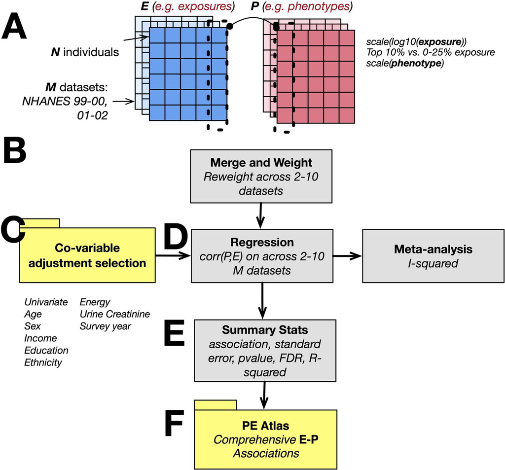

**Figure 6**: The P-ExWAS pipeline. (A) Exposure and phenotype matrices across M NHANES datasets. (B) Merge and reweight across 2-10 datasets. (C) Nine covariate adjustment models. (D) Survey-weighted regression and meta-analysis. (E) Summary statistics. (F) The PE Atlas.

## Scale of the Analysis

| Metric | Value |
| --- | --- |
| Total possible associations | 563,627 |
| After filtering (\(n \geq 500\), \(\geq 2\) waves) | **119,643** |
| Unique phenotypes | 305 |
| Unique exposures | 619 |
| NHANES waves | 10 (1999-2018) |
| Median sample size per test | 7,464 (IQR 4,220-15,316) |

This is ExWAS at an unprecedented scale — and all of it powered by the `nhanespewas` package.

## The nhanespewas Pipeline (Recap)

The atlas was built using exactly the tools from Modules 4-5:

```r
library(nhanespewas)
con <- connect_pewas_data()

# For each phenotype-exposure pair:
result <- pe_flex_adjust(
  phenotype = "LBXTC",     # e.g., total cholesterol
  exposure = "LBXBPB",     # e.g., blood lead
  adjustment_model = adjustment_models[[9]],  # full model
  con = con
)

# Meta-analyze across waves with UWLS
meta <- stanley_meta(
  estimates = per_wave_estimates,
  standard_errors = per_wave_ses
)
```

## Exposure Transformation

Consistent with Module 3, all continuous exposures were:

1. **Log₁₀-transformed** (not natural log) to handle right-skew
2. **Standardized** to mean = 0, SD = 1 within each wave
3. Values below the **lower limit of detection (LLOD)**: set to LLOD/\(\sqrt{2}\)

Phenotypes were also scaled to enable cross-phenotype comparison.

**Interpretation**: each coefficient (\(\beta\)) represents the SD change in phenotype per 1 SD change in log₁₀(exposure).

## The Full Adjustment Model

The primary model (Model 9 of 9) adjusted for:

\[P = \beta_0 + \beta_1 E + \gamma_1 \text{age} + \gamma_2 \text{age}^2 + \gamma_3 \text{sex} + \gamma_4 \text{income} + \gamma_5 \text{ethnicity} + \gamma_6 \text{education} + \gamma_7 \text{wave} + \epsilon\]

Nine adjustment models were tested (Module 4’s `adjustment_models` framework), from unadjusted to fully adjusted — enabling sensitivity analysis.

## Sensitivity to Adjustment

**15% of significant findings showed a sign reversal** between the unadjusted and fully adjusted models.

Example: Blood cadmium and BMI

- **Unadjusted**: positive association (cadmium ↑ → BMI ↑)
- **Fully adjusted**: negative association (cadmium ↑ → BMI ↓)

This highlights why **confounder adjustment matters** (Module 3) — and why running multiple adjustment models (Module 4) is essential.

## Meta-Analysis Across 10 Waves

The UWLS meta-analytic method (Module 7) pooled estimates across NHANES waves:

```r
# For each exposure-phenotype pair, meta-analyze across waves
meta_result <- stanley_meta(
  estimates = per_wave_betas,
  standard_errors = per_wave_ses
)
```

**Heterogeneity (I²)** assessed stability across time:

| Waves available | Median I² |
| --- | --- |
| 2 | 0% |
| 5 | 26% |
| 10 | 18% |

Most associations are consistent over time; some show temporal trends.

## Multiple Testing Correction

With ~120,000 tests, stringent correction is essential:

| Method | Threshold | Significant |
| --- | --- | --- |
| Bonferroni | \(p < 4 \times 10^{-7}\) | **5,674** (5%) |
| Benjamini-Yekutieli FDR | \(p < 5.1 \times 10^{-4}\) | **15,386** (12%) |

The BY-FDR (more conservative than BH-FDR) was used because exposures are **correlated** — standard BH-FDR assumes independence.

## The Associational Architecture of the Exposome

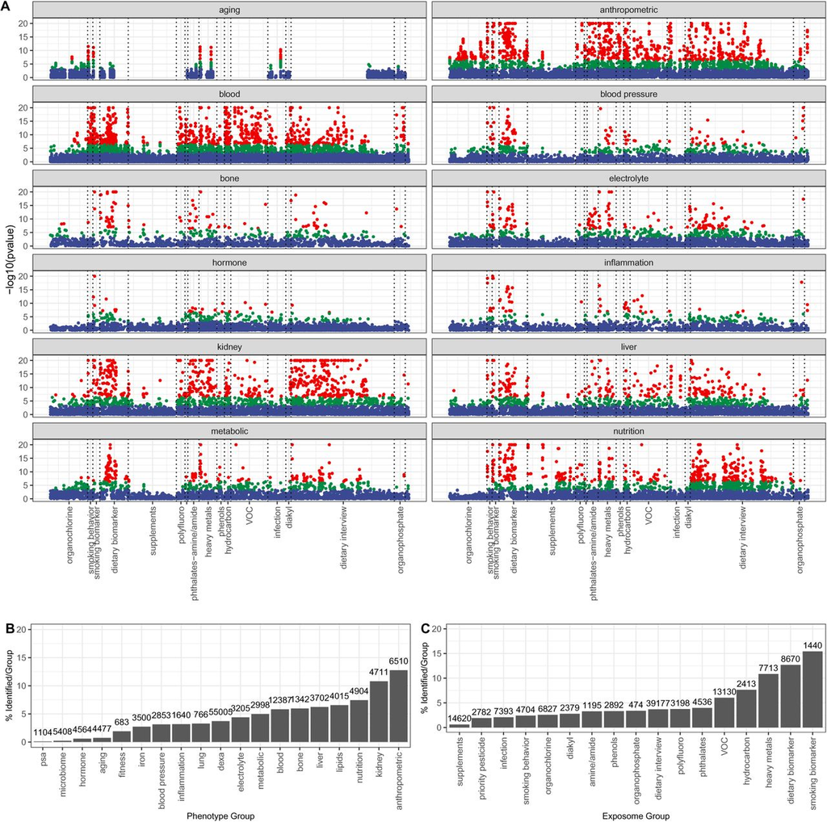

## Which Phenotypes Had the Most Associations?

**Top phenotypes by % of tests reaching Bonferroni significance:**

| Phenotype | % Significant | Tests |
| --- | --- | --- |
| Serum bilirubin | ~20% | 640+ |
| Waist circumference | ~20% | 640+ |
| BMI | ~20% | 640+ |
| Triglycerides | High | 640+ |
| HbA1c | High | 640+ |

Cardiometabolic and anthropometric phenotypes dominate — consistent with the ExWAS literature (Module 1).

## Variance Explained by the Exposome

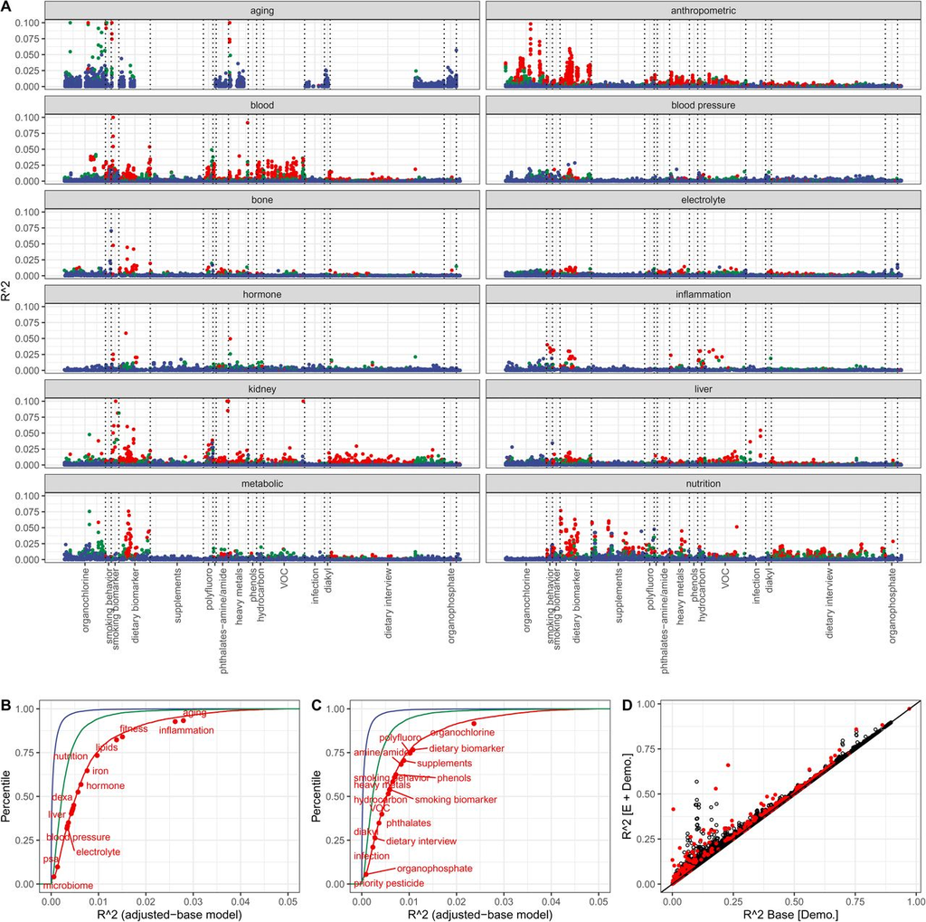

**Figure 3**: (A) R-squared by exposure-phenotype pair. (B-C) Cumulative R-squared by phenotype and exposure category. (D) Base demographic model R-squared vs. expanded model with exposures — points above diagonal show exposures contribute beyond demographics.

## Variance Explained: Key Numbers

Individual exposures explain modest variance, but collectively they add up:

| Model | Median R² |
| --- | --- |
| Single exposure (Bonferroni-significant) | 0.6% (IQR 0.3%-1%) |
| ≤20 exposures | 1.6% (IQR 0.7%-3.5%) |
| Top 20 exposures | **3.5%** (IQR 1.8%-7.9%) |
| Maximum (triglycerides) | **43%** |
| Non-significant (single exposure) | 0.02% |

Most individual effects are small — but the cumulative signal is substantial.

## The Exposome-Phenome Atlas

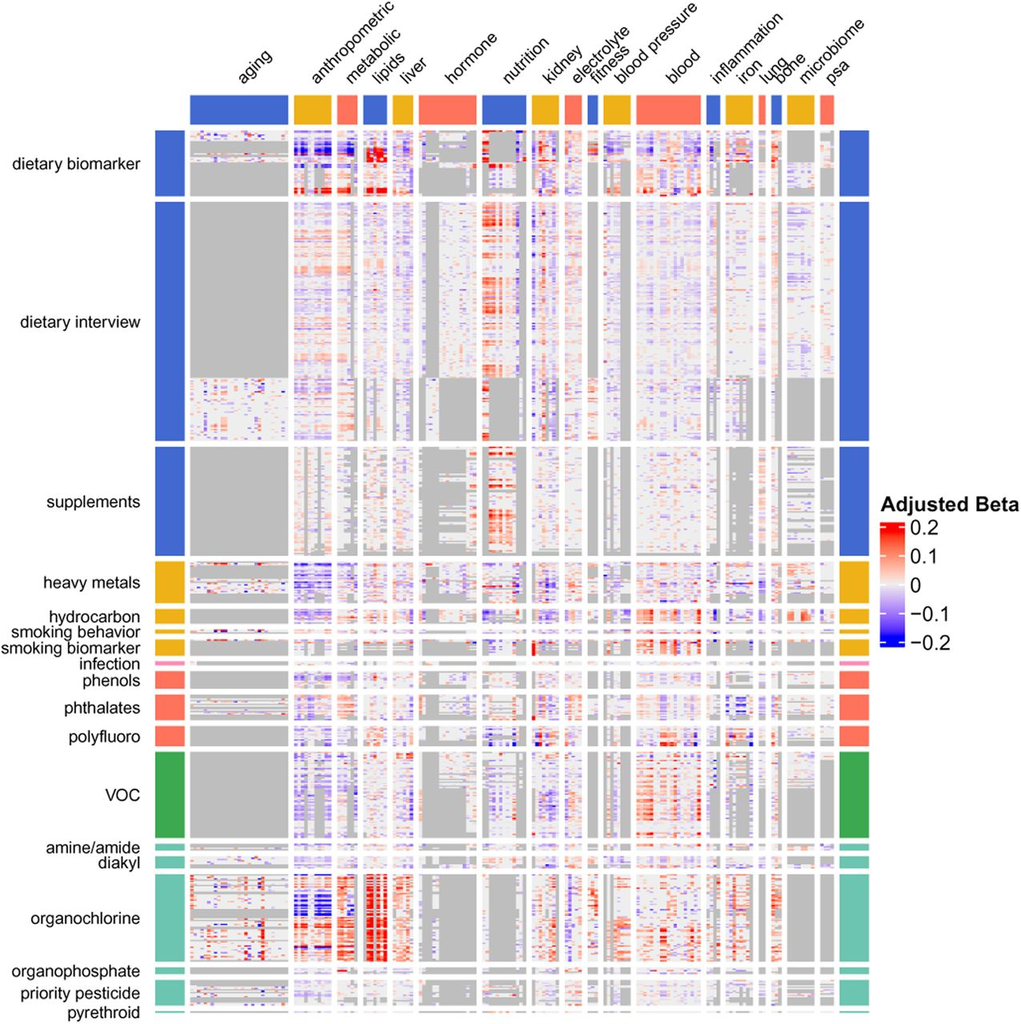

**Figure 4**: The full PE Atlas. Each cell = adjusted beta for one exposure-phenotype pair, meta-analyzed across NHANES waves. Rows = 619 exposures; Columns = 305 phenotypes. Red = positive, blue = negative, grey = insufficient data.

## Reading the Atlas Heatmap

Key patterns in Figure 4:

- **Dietary biomarkers** (top rows): widespread associations across anthropometric, metabolic, and lipid phenotypes
- **Smoking biomarkers**: strong block of associations with blood parameters, pulmonary function, and inflammation
- **Heavy metals**: concentrated associations with kidney function and blood parameters
- **Organochlorines** (bottom): associations with lipids and aging phenotypes — these persistent pollutants accumulate in lipid compartments
- **Grey regions**: data sparsity — not all exposures are measured in all waves

## Triglycerides: The Headline Finding

Triglycerides emerged as the phenotype **most strongly associated** with multi-domain exposures.

**Poly-exposure R² = 43%** (20 exposures simultaneously)

Top contributors:

| Exposure | Direction | Category |
| --- | --- | --- |
| Trans,trans-9,12-octadecadienoic acid | + | Trans fatty acid |
| Alpha-tocopherol | + | Vitamin E |
| Gamma-tocopherol | + | Vitamin E |
| Persistent organochlorines | + | Lipophilic pollutants |

Trans fats and lipophilic pollutants accumulate in the same lipid compartment as triglycerides.

## BMI: Exposome vs. Genome

For BMI, the study compared exposomic and genomic variance explained:

| Source | R² | Method |
| --- | --- | --- |
| Genetics (UK Biobank PGS) | ~10% | Polygenic score (~1M variants) |
| Exposome (top 20 exposures) | ~10% | Poly-exposure score |

**The exposome explains as much BMI variation as the genome.**

This is a landmark finding — it quantifies the often-hypothesized parity between genetic and environmental contributions.

## Exposome vs. Genome: Across Phenotypes

Across 29 phenotypes with both genetic and exposomic data:

- **Median genetic R²**: 7.9% (IQR 2.8%-9.3%)
- **Median exposomic R²**: 7.9% (IQR 3.1%-12%)
- **55% of phenotypes** (16/29) had higher exposomic than genetic R²

For triglycerides: exposomic R² (43%) far exceeded genetic R² (~8%).

The exposome is not a minor contributor — it is a **major axis of phenotypic variation**.

## Effect Sizes

For Bonferroni-significant associations, standardized effect sizes (\(\beta\)):

- **5th-95th percentile**: \(-0.17\) to \(0.19\)
- **Absolute median**: ~0.06 SD per SD of exposure

These are **small but real** effects — consistent with the expectation that individual environmental factors make modest contributions to complex traits.

## Tobacco and Lung Function

A methodologically important finding comparing two smoking biomarkers:

| Biomarker | Half-life | \(\beta\) on FEV1 | R² |
| --- | --- | --- | --- |
| Urinary NNAL | 10-16 days | \(-0.06\) | 0.20% |
| Serum cotinine | ~16 hours | \(-0.03\) | 0.08% |

**NNAL** (a tobacco-specific carcinogen metabolite) is a better marker than cotinine because its longer half-life captures **cumulative exposure** rather than recent smoking.

**Lesson**: Biomarker choice matters — measurement error attenuates associations (Module 3).

## Biomarkers vs. Self-Report

The atlas compared **objective biomarkers** vs. **self-reported dietary intake**:

| Measurement | Bonferroni associations | Median R² |
| --- | --- | --- |
| Dietary biomarkers (blood/urine) | 1,101 | **1.0%** |
| Self-reported nutrients | 1,452 | 0.2% |

Biomarkers yield **5\(\times\) larger R²** despite fewer significant associations — because they have less measurement error.

Day-to-day self-reported nutrient correlation: \(r = 0.36\) — highlighting instability.

## Exposure Correlation Globes

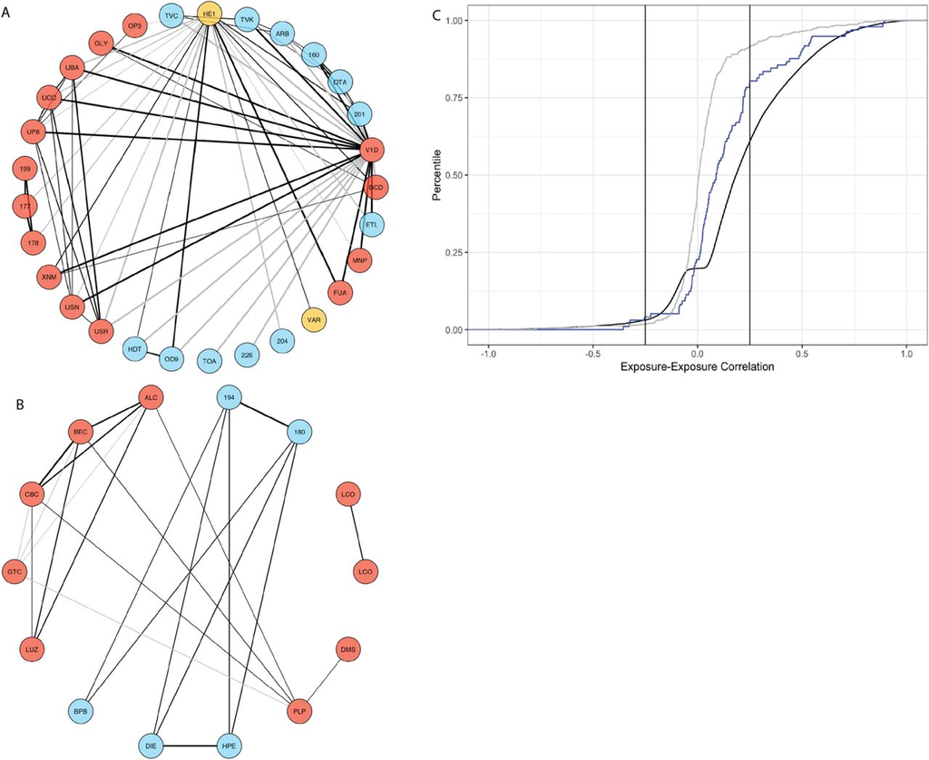

## Reading the Correlation Globes

Key patterns in Figure 5:

- **Red nodes** and **blue nodes** represent different exposure categories
- **Thick dark lines**: strong correlations (\(|r| > 0.25\))
- Heavy metals form a tightly connected cluster (shared environmental sources)
- Smoking biomarkers (cotinine, NNAL, PAHs) are highly interconnected
- Lipophilic pollutants (PCBs, organochlorines) co-accumulate in adipose tissue
- The **dense web** means exposures rarely act in isolation — complicating causal attribution

## Exposure Correlation: By the Numbers

- 200,265 pairwise correlations assessed
- Among Bonferroni-significant pairs: median \(|r| = 0.21\)
- 95th percentile: \(|r| = 0.69\)

Examples of high correlation:

| Exposure Pair | \(r\) | Reason |
| --- | --- | --- |
| Cotinine vs. 3-fluorene (PAH) | 0.90 | Both from tobacco smoke |
| Trans- vs. cis-beta-carotene | 0.98 | Same dietary sources |
| Blood vs. urinary cadmium | 0.78 | Same metal, different matrices |

## Replication Across NHANES Waves

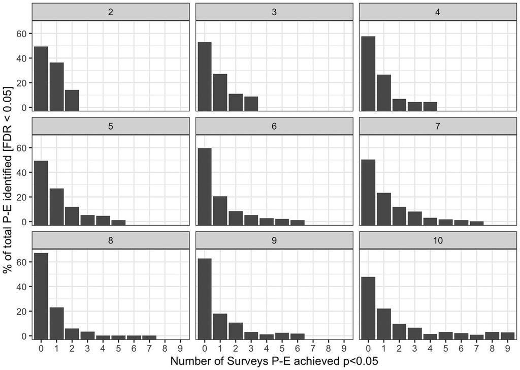

**Figure 7**: Replication rates across NHANES waves. Each facet shows associations available in K waves (2-10). X-axis: number of waves achieving p < 0.05. Y-axis: % of FDR-significant associations.

## Replication: Key Numbers

[output not shown]

Replication rate far exceeds the chance expectation — these are real signals.

## Shared Associational Architecture

Some exposure pairs associate with phenotypes in strikingly similar ways:

| Exposure Pair | Correlation of phenotype profiles |
| --- | --- |
| Blood trans- vs. cis-beta-carotene | \(r = 0.98\) |
| Cotinine vs. 3-fluorene | \(r = 0.90\) |
| BMI vs. body weight | \(r = 0.98\) (phenotypes) |
| BMI vs. cardiorespiratory fitness | \(r = -0.83\) |
| HbA1c vs. HDL cholesterol | \(r = -0.54\) |

Exposures from the **same category** tend to have similar phenotype profiles — but cross-category similarities also exist, revealing shared biology.

## Poly-Exposure Score Construction

The poly-exposure score (analogous to a polygenic score) was built as follows:

1. Select top 20 FDR-significant exposures for each phenotype (univariate)
2. Impute missing data with MICE (10 imputations)
3. Fit baseline model: phenotype \(\sim\) demographics
4. Fit expanded model: phenotype \(\sim\) demographics + 20 exposures
5. \(\Delta R^2\) = expanded \(R^2\) - baseline \(R^2\)

```r
# Conceptual code for poly-exposure score
baseline_r2 <- glance(lm(phenotype ~ age + sex + race + income,
                         data = nhanes))$r.squared
expanded_r2 <- glance(lm(phenotype ~ age + sex + race + income +
                          E1 + E2 + ... + E20,
                         data = nhanes))$r.squared
delta_r2 <- expanded_r2 - baseline_r2
```

## Reproducing Key Findings with nhanespewas

You can reproduce these results using the tools from this course:

```r
library(nhanespewas)
con <- connect_pewas_data()

# Run the triglycerides ExWAS
trig_results <- map_dfr(e_catalog$var, function(exp_var) {
  tryCatch({
    result <- pe_flex_adjust("LBXTR", exp_var,
                             adjustment_models[[9]], con)
    result %>%
      map_dfr(~ tidy(.), .id = "wave") %>%
      filter(grepl(exp_var, term)) %>%
      summarize(exposure = exp_var,
                estimate = mean(estimate),
                p.value = min(p.value))
  }, error = function(e) NULL)
})

# Apply FDR
trig_results <- trig_results %>%
  mutate(fdr = p.adjust(p.value, method = "BY"))
```

## Meta-Analyzing Across Waves

```r
# For a single exposure-phenotype pair across waves:
result <- pe_flex_adjust("LBXTR", "LBXBPB",
                          adjustment_models[[9]], con)

per_wave <- result %>%
  map_dfr(~ tidy(.), .id = "wave") %>%
  filter(grepl("LBXBPB", term))

# UWLS meta-analysis (as used in the atlas)
meta <- stanley_meta(per_wave$estimate, per_wave$std.error)

# Compare with DerSimonian-Laird
library(metafor)
rma_fit <- rma(yi = per_wave$estimate,
               sei = per_wave$std.error, method = "DL")
```

## Key Lessons from the Atlas

1. **Scale matters**: testing 120K associations reveals patterns invisible in single studies
2. **Replication is achievable**: 41% of Bonferroni hits replicate across independent waves
3. **Exposome \(\approx\) Genome**: poly-exposure scores rival polygenic scores for many traits
4. **Measurement quality matters**: biomarkers >> self-report for R²
5. **Confounders can flip signs**: 15% of associations reverse direction after adjustment
6. **Exposures are correlated**: complicates causal attribution, requires careful interpretation
7. **Small individual effects, large cumulative signal**: median \(\beta \approx 0.06\), but 20 exposures can explain 3.5-43% of variance

## Limitations and Open Questions

The atlas authors acknowledge:

- **Cross-sectional design**: cannot establish temporality or causation
- **Correlation \(\neq\) causation**: confounding, reverse causation remain
- **Missing exposures**: NHANES doesn’t measure everything (air pollution, noise, psychosocial stress)
- **Single time-point**: doesn’t capture exposure trajectories
- **US-specific**: may not generalize globally

**Future directions**: longitudinal exposomics, Mendelian randomization, mediation analysis (requires longitudinal data to establish temporality), multi-omics integration (proteomics, metabolomics, methylomics)

## Data and Code Availability

All resources are publicly available:

| Resource | Location |
| --- | --- |
| `nhanespewas` R package | https://github.com/chiragjp/nhanespewas |
| PE Atlas web tool | https://pe.exposomeatlas.com |
| Full cohort database | doi: 10.6084/m9.figshare.29182196 |
| Summary statistics | doi: 10.6084/m9.figshare.29186171 |
| Tutorials | `pe_quickstart.Rmd`, `exwas_tour.Rmd`, `pe_catalog.Rmd` |

You have all the tools to reproduce, extend, and build on this work.

## Your Turn: Exercise Ideas

1. **Reproduce a finding**: Pick a phenotype from the atlas, run the ExWAS with `nhanespewas`, and compare your results to the published atlas
2. **New phenotype**: Choose a phenotype not in the atlas and run your own ExWAS
3. **Sensitivity analysis**: Compare results across all 9 adjustment models for your top hits
4. **Meta-analysis**: Run per-wave estimates and build forest plots for a replicated finding
5. **Correlation globe**: Visualize the exposure correlation structure for your top hits

## Course Summary

| Module | What You Learned |
| --- | --- |
| 1 | The exposome concept, NHANES, E-G-P-D framework |
| 2 | Tidyverse data manipulation and visualization |
| 3 | Survey-weighted regression, FDR, standardization |
| 4 | The nhanespewas package and database |
| 5 | Building and running the ExWAS loop |
| 6 | Volcano plots, replication, sensitivity analysis |
| 7 | Meta-analysis, interactions, advanced methods |
| 8 | AI agents for accelerating ExWAS |
| **9** | **Full-scale application: the Phenome-Exposome Atlas** |

## The Big Picture

The Patel, Ioannidis, and Manrai atlas demonstrates that:

> The exposome is not a minor perturbation on a genetic background — it is a **co-equal axis** of phenotypic variation, with poly-exposure models matching or exceeding polygenic scores for the majority of tested phenotypes.

With the tools from this course — `nhanespewas`, survey-weighted regression, FDR, meta-analysis, and the PE Atlas — you are equipped to **contribute to this field**.

## Thank You

**Congratulations on completing the course!**

The exposome is vast. The tools are ready. The atlas is public.

Now it’s your turn to explore.

**Reference:**

Patel CJ, Ioannidis JPA, Manrai AK. An atlas of exposome-phenome associations in health and disease risk. *Nature Medicine*, in press. doi: 10.1101/2025.06.05.25329055